# Project

Sal Trevino

5/11/2021

## Q1 – Read in the ities.csv and max_temp.csv as dataframe objects *df* and *df_weather_weekly*, respectively.

```r
# Import Libraries.----
library(tidyverse)
library(magrittr)
library(lubridate)
# Reads in the ities.csv and max_temp.csv as dataframe objects df and df_weather_weekly.----
df <- read.csv('ities.csv')
df_weather_weekly <- read.csv('max_temp.csv')
```

## Q2 – Display the number of rows and columns in *df* and *df_weather_weekly*, respectively, using an appropriate R function.

–Number of rows and columns for the *df* dataframe:

```r
# Tells how many rows and columns are in the df dataframe.----
dim(df)
```

```
## [1] 438151     13
```

The *df* dataframe has 438,151 rows and 13 columns.

*Number of rows and columns for the* **df_weather_weekly*** dataframe:

```r
# Tells how many rows and columns are in the df_weather_weekly dataframe.----
dim(df_weather_weekly)
```

```
## [1] 52  9
```

The *df_weather_weekly* dataframe has 52 rows and 9 columns.

## Q3 – Display the structures of the dataframes, *df* and *df_weather_weekly*. Below the output, comment on the appropriateness of the datatypes for the columns.

*Structure of the* **df*** dataframe:

```r
# Provides an overview of the structure of the df dataframe.----
str(df)
```

```
## 'data.frame':    438151 obs. of  13 variables:
##  $ Date             : chr  "7/18/2016" "7/18/2016" "7/18/2016" "7/18/2016" ...
##  $ OperationType    : chr  "SALE" "SALE" "SALE" "SALE" ...
##  $ CashierName      : chr  "Wallace Kuiper" "Wallace Kuiper" "Wallace Kuiper" "Wallace Kuiper" ...
##  $ LineItem         : chr  "Salmon and Wheat Bran Salad" "Fountain Drink" "Beef and Squash Kabob" "Salmon and Wheat Bran Salad" ...
##  $ Department       : chr  "Entrees" "Beverage" "Kabobs" "Salad" ...
##  $ Category         : chr  "Salmon and Wheat Bran Salad" "Fountain" "Beef" "general" ...
##  $ RegisterName     : chr  "RT149" "RT149" "RT149" "RT149" ...
##  $ StoreNumber      : chr  "AZ23501305" "AZ23501289" "AZ23501367" "AZ23501633" ...
##  $ TransactionNumber: chr  "002XIIC146121" "002XIIC146121" "00PG9FL135736" "00Z3B4R37335" ...
##  $ CustomerCode     : chr  "CWM11331L8O" "CWM11331L8O" "CWM11331L8O" "CWM11331L8O" ...
##  $ Price            : num  66.22 2.88 12.02 18.43 18.43 ...
##  $ Quantity         : int  1 1 2 1 1 1 1 1 1 1 ...
##  $ TotalDue         : num  66.22 2.88 24.04 18.43 18.43 ...
```

```r
# Provides an overview of the features of the df dataframe.----
names(df)
```

```
##  [1] "Date"              "OperationType"     "CashierName"
##  [4] "LineItem"          "Department"        "Category"
##  [7] "RegisterName"      "StoreNumber"       "TransactionNumber"
## [10] "CustomerCode"      "Price"             "Quantity"
## [13] "TotalDue"
```

*Structure of the* **df_weather_weekly*** dataframe:

```r
# Provides an overview of the structure of the df_weather_weekly dataframe.----
str(df_weather_weekly)
```

```
## 'data.frame':    52 obs. of  9 variables:
##  $ Week        : int  1 2 3 4 5 6 7 8 9 10 ...
##  $ Monday      : num  46.9 48.9 48 34 51.1 ...
##  $ Tuesday     : num  45 46 52 41 60.1 ...
##  $ Wednesday   : num  41 46 53.1 51.1 57.9 ...
##  $ Thursday    : num  45 46.9 55 46.9 51.1 ...
##  $ Friday      : num  59 51.1 50 55.9 41 ...
##  $ Saturday    : num  57 42.1 51.1 51.1 48 ...
##  $ Sunday      : num  57 48.9 50 36 52 ...
##  $ WeekStarting: chr  "1/3/16" "1/10/16" "1/17/16" "1/24/16" ...
```

```r
# Provides an overview of the features of the df dataframe.----
names(df_weather_weekly)
```

```
## [1] "Week"         "Monday"       "Tuesday"      "Wednesday"    "Thursday"
## [6] "Friday"       "Saturday"     "Sunday"       "WeekStarting"
```

Both datatypes (df and df_weather_weekly) are appropriate because the data provided is in a tidy format. Observations and features are well structured and, if needed, it is easy to comibine both dataframes via a common column (characteristic) which is by using the date column.

## Q4 – Display summaries of the columns in the dataframes, *df* and *df_weather_weekly*.

*Summary of the df dataframe:

```r
# Provides summary of the df dataframe.----
summary(df)
```

```
##      Date           OperationType      CashierName          LineItem
##  Length:438151      Length:438151      Length:438151      Length:438151
##  Class :character   Class :character   Class :character   Class :character
##  Mode  :character   Mode  :character   Mode  :character   Mode  :character
##
##
##
##
##   Department          Category         RegisterName       StoreNumber
##  Length:438151      Length:438151      Length:438151      Length:438151
##  Class :character   Class :character   Class :character   Class :character
##  Mode  :character   Mode  :character   Mode  :character   Mode  :character
##
##
##
##
##  TransactionNumber  CustomerCode           Price             Quantity
##  Length:438151      Length:438151      Min.   :-5740.51   Min.   :  1.000
##  Class :character   Class :character   1st Qu.:    4.50   1st Qu.:  1.000
##  Mode  :character   Mode  :character   Median :   11.29   Median :  1.000
##                                        Mean   :   14.36   Mean   :  1.177
##                                        3rd Qu.:   14.68   3rd Qu.:  1.000
##                                        Max.   :21449.97   Max.   :815.000
##                                        NA's   :12
##     TotalDue
##  Min.   :-5740.51
##  1st Qu.:    4.50
##  Median :   11.80
##  Mean   :   15.26
##  3rd Qu.:   15.04
##  Max.   :21449.97
##  NA's   :12
```

*Summary of the df dataframe:

```r
# Provides summary of the df_weather_weekly dataframe.----
summary(df_weather_weekly)
```

```
##       Week           Monday          Tuesday         Wednesday
##  Min.   : 1.00   Min.   : 33.98   Min.   : 28.94   Min.   : 30.92
##  1st Qu.:13.75   1st Qu.: 48.92   1st Qu.: 50.00   1st Qu.: 51.98
##  Median :26.50   Median : 67.46   Median : 68.00   Median : 65.93
##  Mean   :26.50   Mean   : 68.29   Mean   : 68.12   Mean   : 69.19
##  3rd Qu.:39.25   3rd Qu.: 88.30   3rd Qu.: 87.58   3rd Qu.: 89.28
##  Max.   :52.00   Max.   :100.94   Max.   :100.94   Max.   :102.02
##     Thursday          Friday          Saturday          Sunday
##  Min.   : 30.92   Min.   : 33.08   Min.   : 28.94   Min.   : 33.98
##  1st Qu.: 50.54   1st Qu.: 55.45   1st Qu.: 53.96   1st Qu.: 51.98
##  Median : 67.01   Median : 65.03   Median : 68.54   Median : 70.52
##  Mean   : 69.41   Mean   : 70.68   Mean   : 70.58   Mean   : 69.25
##  3rd Qu.: 89.56   3rd Qu.: 91.27   3rd Qu.: 89.56   3rd Qu.: 89.96
##  Max.   :100.94   Max.   :104.00   Max.   :102.02   Max.   :102.92
##  WeekStarting
##  Length:52
##  Class :character
##  Mode  :character
##
##
##
```

## Q5 – Display the missing values, if any, in *df*. You can choose to remove or input the missing values and defend that choice in 1-2 sentences for each column with missing values.

*Missing values in df dataframe:

```r
# Displaying missing values of the df dataframe.----
colSums(is.na(df))
```

```
##              Date     OperationType       CashierName          LineItem
##                 0                 0                 0                 0
##        Department          Category      RegisterName       StoreNumber
##                 0                 0                 0                 0
## TransactionNumber      CustomerCode             Price          Quantity
##                 0                 0                12                 0
##          TotalDue
##                12
```

*Dealing with missing values in df dataframe:

```r
# Inputing missing values with mean.----
df_nona1 <- df %>%
  mutate(
    Price = ifelse(is.na(Price), mean(Price, na.rm = T), Price)
    , Price
  ) %>%
  ungroup()
```

```r
# Inputing missing values with mean.----
df_nona2 <- df_nona1 %>%
  mutate(
    TotalDue = ifelse(is.na(TotalDue), mean(TotalDue, na.rm = T), TotalDue)
    , TotalDue
  ) %>%
  ungroup()
```

```r
# Displaying missing values of the df dataframe.----
summary(df_nona2)
```

```
##      Date           OperationType      CashierName          LineItem
##  Length:438151      Length:438151      Length:438151      Length:438151
##  Class :character   Class :character   Class :character   Class :character
##  Mode  :character   Mode  :character   Mode  :character   Mode  :character
##
##
##
##   Department          Category         RegisterName       StoreNumber
##  Length:438151      Length:438151      Length:438151      Length:438151
##  Class :character   Class :character   Class :character   Class :character
##  Mode  :character   Mode  :character   Mode  :character   Mode  :character
##
##
##
##  TransactionNumber  CustomerCode           Price             Quantity
##  Length:438151      Length:438151      Min.   :-5740.51   Min.   :  1.000
##  Class :character   Class :character   1st Qu.:    4.50   1st Qu.:  1.000
##  Mode  :character   Mode  :character   Median :   11.29   Median :  1.000
##                                        Mean   :   14.36   Mean   :  1.177
##                                        3rd Qu.:   14.68   3rd Qu.:  1.000
##                                        Max.   :21449.97   Max.   :815.000
##     TotalDue
##  Min.   :-5740.51
##  1st Qu.:    4.50
##  Median :   11.80
##  Mean   :   15.26
##  3rd Qu.:   15.04
##  Max.   :21449.97
```

```r
colSums(is.na(df_nona2))
```

```
##              Date     OperationType       CashierName          LineItem
##                 0                 0                 0                 0
##        Department          Category      RegisterName       StoreNumber
##                 0                 0                 0                 0
## TransactionNumber      CustomerCode             Price          Quantity
##                 0                 0                 0                 0
##          TotalDue
##                 0
```

Since we have a large enough sample of historical data on price we can fill in the missing prices with the average price for the 12 observations that are missing values. Once we have those missing prices, we can proceed with also removing any NA missing values for the TotalDue column as well. By doing this, we end up with a complete dataframe, void of any NA missing values.

## Q6 – Create a new dataset *df_daily* by aggregating the dataframe *df* at the *daily* level. The dataframe *df_daily* must have the columns *Quantity* and *TotalDue* from *df* summarized at the daily level. In one to two sentences, defend the choice of the summary measure (sum, mean, or other) used to aggregate the values in each column.

```r
# Aggregating df_daily dataframe so that we now have a "Quantity" and "TotalDue" column.----
df_daily <- df_nona2 %>%
  mutate(
    Date = mdy(Date)
    , date = round_date(Date, 'day')
  ) %>%
  group_by(date) %>%
  summarise(TotalDue = mean(TotalDue, na.rm = T)
            , Quantity = mean(Quantity, na.rm = T)) %>%
  ungroup()
summary(df_daily)
```

```
##       date               TotalDue         Quantity
##  Min.   :2014-01-04   Min.   :-37.41   Min.   : 1.000
##  1st Qu.:2014-10-25   1st Qu.: 12.35   1st Qu.: 1.114
##  Median :2015-08-17   Median : 13.56   Median : 1.148
##  Mean   :2015-08-18   Mean   : 16.07   Mean   : 1.205
##  3rd Qu.:2016-06-11   3rd Qu.: 16.30   3rd Qu.: 1.210
##  Max.   :2017-04-05   Max.   :391.00   Max.   :14.000
```

I chose to use the average (mean) summary measure when aggregating the values in each colum because it provides a snapshot of the quantity customers are purchasing each day and, on average, and how much they are on average spending. We can look at individual days and compare that to the overall average in quantity and total due data set for the entire sample and try to understand trends for when customer purchases increase or decrease.

## Q7 – Convert the dataframe *df_weather_weekly* from *wide to long* such that names of the seven columns (Monday:Sunday) are in a new column *day* and the values from those seven columns (Monday:Sunday) are in a new column *max_temp*. The name of the long dataframe will be *df_weather_daily*.

```r
# Converting the df_weather_weekly dataframe from a wide column to a long column.----
df_weather_daily <- df_weather_weekly %>%
  pivot_longer(cols = Monday:Sunday
               , names_to = 'day'
               , values_to = 'max_temp')
```

```r
# Converting character strings to dates on the df_weather_daily table.----
df_weather_daily$WeekStarting <- as.Date(df_weather_daily$WeekStarting, format = '%m/%d/%y')
```

```r
# Renaming the WeekStarting column to a common name across both tables so that they can be joined.----
df_weather_daily <- df_weather_daily %>% rename(date = WeekStarting)
```

```r
# Joining the df_daily and df_weather_daily into one final, single table.----
df_final <- df_weather_daily %>%
  full_join(df_daily, by = 'date')
```

## Q9 – Display a pairplot like the one demonstrated in the “Getting to Know Your Data 3: Summary Statistics for Each Column, and Quick Plots” video of module 2 (e.g., plot(iris[,c(‘Sepal.Length’, ‘Sepal.Wdith’, ‘Petal.Length’)])). Create this pairplot for three columns from *df_final*: Quantity, TotalDue, and max_temp. Below the output, interpret the scatter plots that are in the pairpot.

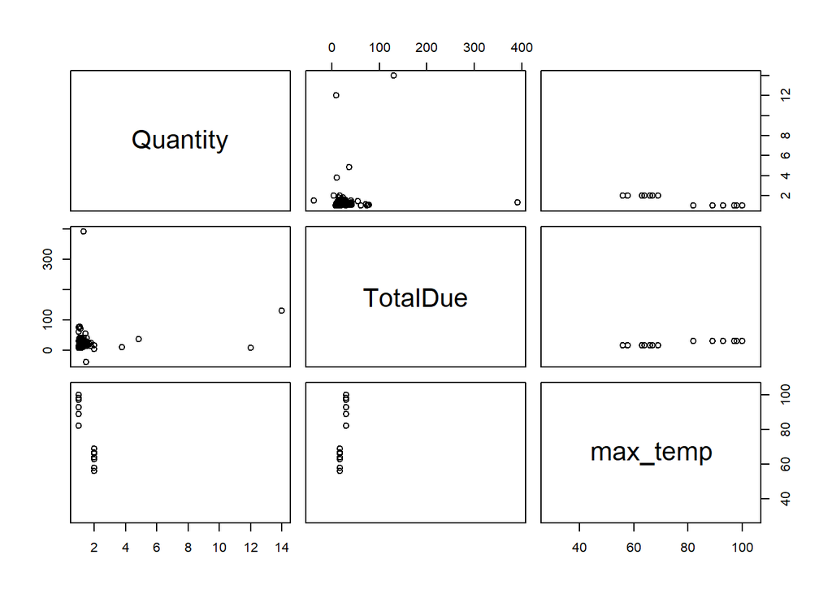

```r
# Visually exploring the shape of the data----
plot(df_final[,c('Quantity', 'TotalDue', 'max_temp')])
```